# Machine Learning - Learning Lab 4 Badge

Ya Zhang

July 16, 2022

[figure not shown]

As a reminder, to earn a badge for each lab, you are required to respond to a set of prompts for two parts:

- In Part I, you will reflect on your understanding of key concepts and begin to think about potential next steps for your own study.
- In Part II, you will create a simple data product in R that demonstrates your ability to apply an analytic technique introduced in this learning lab.

### Part I: Reflect and Plan

Part A:

1. How interpretable or useful is the solution we estimated in the case study?
- I selected 3 variables to run the case study (ave_carelessness_scaled, ave_res_bored_scaled, ave_correct_scaled). I found the results to be interpretatble as when I looked at the patterns of the four group on these three variables, I was able to group their patterns and make sense of the results. I think for the next step I’d do some hypothesis testing to check the differences among these profiles.
2. How might a qualitative analysis follow from the Latent Profile Analysis we carried out? What steps could you take in a qualitative investigation? Feel free to think broadly and creatively here!
- There’re different ways to do the qualitative analysis afterwards. For the simplest way I’d plot the counts of the profiles. In addition to the qualitative analysis, I think inferential statistics can be run to check the significant difference between the profiles. I’ll definitely be interested in going beyond the qualitative analysis.

Part B: Once again, use the institutional library (e.g. [NCSU Library](https://www.lib.ncsu.edu/#articles)), [Google Scholar](https://scholar.google.com/) or search engine to locate a research article, presentation, or resource that applies unsupervised machine learning to an educational context aligned with your research interests. More specifically, **locate a machine learning study that involve using Latent Profile Analysis or a similar method**. You may find the published papers that have used LPA helpful in this respect; those can be browsed [here](https://scholar.google.com/scholar?hl=en&as_sdt=0%2C34&q=tidylpa&btnG=).

1. Provide an APA citation for your selected study.
   - van Alten, D. C., Phielix, C., Janssen, J., & Kester, L. (2021). Secondary students’ online self-regulated learning during flipped learning: A latent profile analysis. Computers in Human Behavior, 118, 106676.
2. What research questions were the authors of this study trying to address and why did they consider these questions important?
   - Whether the differences in students’ self-regulated learning (SRL) skills should form the basis for tailoring SRL support in online learning environments? Whether students’ SRL activity profile membership can be explained by their characteristics (i.e., self-reported SRL, motivation, and prior knowledge)?
3. What were the results of these analyses?
   - Five distinct SRL profiles from low completion and no activity to full completion and very high activity. In addition, students in the profile who showed low SRL activity achieved significantly worse learning outcomes than students in the three profiles with higher SRL activity. However, none of the student level variable was found to predict their profile membership.

### Part II: Data Product

Like the last data product, this one may be a challenge, too. Here, estimate latent profiles using *your own data*. If you do not have ready access to appropriate data (for LPA, continuous/numeric data), choose any of the data sets in the `data` folder of this repository.

Some code is provided below as a starting point.

```r
library(tidyverse)
library(tidyLPA)
d <- read_csv("data/dat_csv_combine_final_full.csv")
d <- d %>%
    select(AveCarelessness, AveKnow, AveCorrect = AveCorrect.x, AveResBored,
           AveResEngcon, AveResConf, AveResFrust, AveResOfftask,
           AveResGaming, NumActions) %>%
    janitor::clean_names()

scale_data <- function(x) {
    x = x - mean(x, na.rm = TRUE)
    x = x / sd(x, na.rm = TRUE)
    x
}

d <- d %>%
    mutate_all(funs(scaled = scale_data)) %>% # using our function to scale all of the variables
    select(contains("_scaled")) # selecting only the scaled version
d %>%
    estimate_profiles(1:10) %>%
    compare_solutions()
```

```
## Compare tidyLPA solutions:
##
##  Model Classes BIC
##  1     1       14701.523
##  1     2       13569.547
##  1     3       12410.738
##  1     4       11845.334
##  1     5       11509.506
##  1     6       11274.194
##  1     7       11129.023
##  1     8       10932.234
##  1     9       10805.967
##  1     10      10688.745
##
## Best model according to BIC is Model 1 with 10 classes.
##
## An analytic hierarchy process, based on the fit indices AIC, AWE, BIC, CLC, and KIC (Akogul & Erisoglu, 2017), suggests the best solution is Model 1 with 10 classes.
```

[figure not shown]

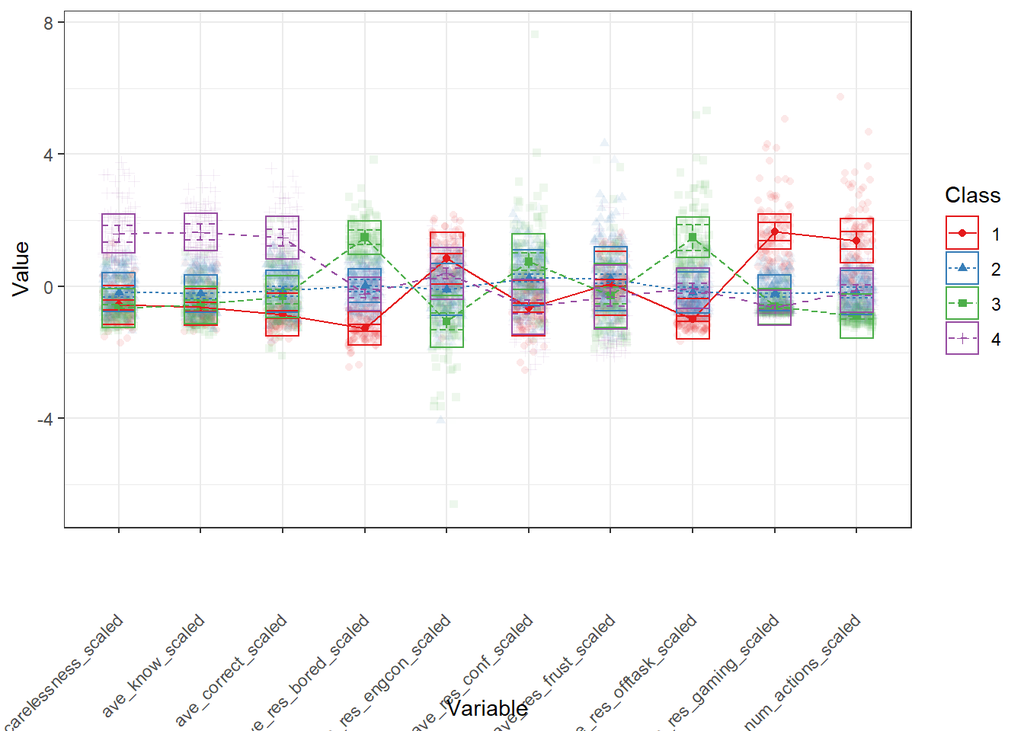

```r
our_solution <- d %>%
    estimate_profiles(4)

plot_profiles(our_solution, add_line = TRUE) +
    theme(axis.text.x = element_text(angle = 45, vjust = 0.5, hjust=1))
```

Please interpret the results of your analysis below. What did you find? How interpretable and useful are the profiles? And, what next steps - including those involving qualitative analysis - might you take to deepen this analysis?

### Knit & Submit

1. Change the name of the `author:` in the [YAML header](https://monashdatafluency.github.io/r-rep-res/yaml-header.html) at the very top of this document to your name. As noted in [Reproducible Research in R](https://monashdatafluency.github.io/r-rep-res/index.html), The YAML header controls the style and feel for knitted document but doesn’t actually display in the final output.
2. Click the yarn icon above to “knit” your data product to a [HTML](https://bookdown.org/yihui/rmarkdown/html-document.html) file that will be saved in your R Project folder.
3. Commit your changes in GitHub Desktop and push them to your online GitHub repository.
4. Publish your HTML page the web using one of the following [publishing methods](https://rpubs.com/cathydatascience/518692):
   - Publish on [RPubs](https://rpubs.com) by clicking the “Publish” button located in the Viewer Pane when you knit your document. Note, you will need to quickly create a RPubs account.
   - Publishing on GitHub using either [GitHub Pages](https://pages.github.com) or the [HTML previewer](http://htmlpreview.github.io).
5. Post a new discussion on GitHub to our [ML badges forum](https://github.com/orgs/laser-institute/teams/machine-learning/discussions/2). In your post, include a link to your published web page and a short reflection highlighting one thing you learned from this lab and one thing you’d like to explore further.